# Project 2

STATS 220 Semester One 2023

Sam Mason

2023-03-26

## Introduction

The aspects of learning preferences/habits i decided to focus on was how many hours per week they spent on learning to code with their preferred option to learn how to code, and their years of experience with their programming language with most experience.

I considered guideline 3 in designing the questions so people with or without experience in coding could have an answer for all questions, and designed them so the people with experience had options that would relate to them, through using common programming languages and common ways of learning to code.

The categorical data generated from the check boxes will not be tidy because for each response the data collected will be assigned to one column with each option selected being separated by a comma. This shows that the data is not tidy as the selected options do not have a cell of their own.

[Link to my Google form](https://forms.gle/6Do8fUqWDMhVH1mF7)

## Analytics

[Link to my published csv file](https://docs.google.com/spreadsheets/d/e/2PACX-1vQTN098ilAXnSiyKq3qDnxF42IgFZ4ZARN2L6TEq5B0kck-GeipfNLqA9vIQ4gyBy-AqaBSKf_ta9Pc/pub?output=csv)

**In total, 20 people completed my form.**

The responses of how many hours spent on learning to code per week, had a mean of **6.15**, a minimum of **0**, a lower quartile of **4.75**, a median of **6**, a upper quartile of **8**, and a maximum of **14**.

The responses of how many years of coding experience they have, had a mean of **2.4**, a minimum of **0**, a lower quartile of **1**, a median of **2**, a upper quartile of **3**, and a maximum of **8**.

**The plot below shows participants preferred option of learning to code with if they had previous coding experience filled in.**

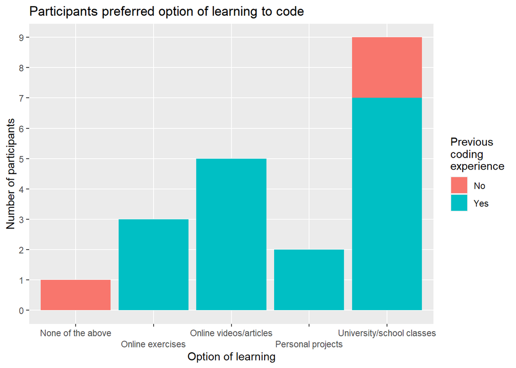

**The plot below shows participants programming language that they have the most experience with.**

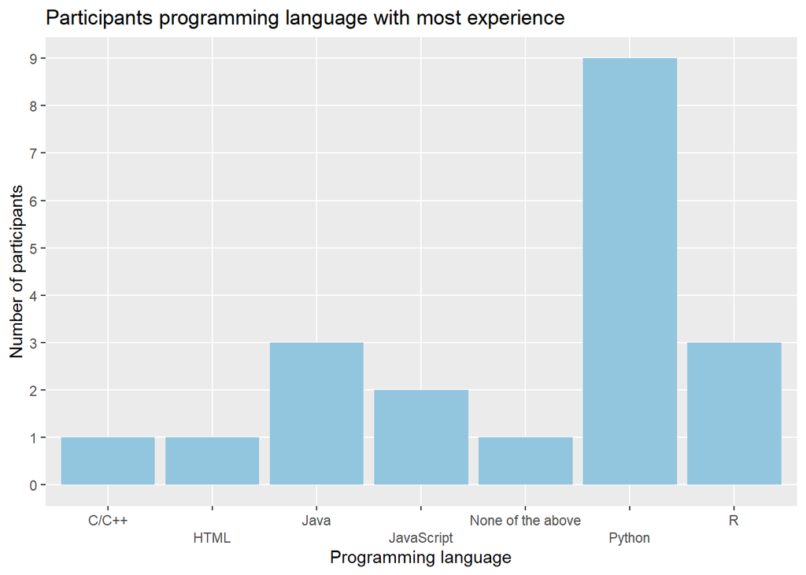

## Learning reflection

An important idea i learned from Module 2 Creating dynamic reporting systems, is using code chunks and inline code for having the data written dynamically. As more data could be collected and the overall data would change, having code that changes depending on the values and number of participants that have completed the survey would produce different outputs and have output that is up to date with the current data. Overall if output can be dynamically changed from new survey data, having the markdown dynamically react to that new data is very beneficial to displaying correct values and helping the reader understand the data.

My project displays creativity by using code for my bar plots to properly show titles, labels, and number of values correctly in a readable view so the reader can easily identify what the analysis section of the report is showing. I have also used css to change the titles of each part and the project title to a more readable and visually identifiable. Finally i have changed important numeric values to be in bold for more readability.

Things related to data technologies i am more curious about exploring further is the continuation of using data through r code. How to lay out different types of data and have it visually shown on a report that uses more advanced functions and techniques to further give a more insightful and effective view of the data.